# Assignment4

Robby Waxman

2/26/2021

```r
#Install and import libraries if needed
if (!require('tidyverse')) install.packages('tidyverse')
library('tidyverse')
if (!require('devtools')) install.packages('devtools')
```

```r
library('devtools')
if (!require('ggplot2')) install.packages('ggplot2')
library('ggplot2')
if (!require('ggmosaic')) install.packages('ggmosaic')
library('ggmosaic')

devtools::install_github("bcaffo/MRIcloudT1volumetrics")
MRIcloudT1volumetrics::readFileList("https://raw.githubusercontent.com/neuroconductor/kirby21.mricloud/master/inst/visit_1/127/kirby_3_1_ax_283Labels_M2_corrected_stats.txt")
```

## Question 1

Download the first Kirb21 subject data here. Use this package to read in the first subject. Calculate and report the intracranial volume: the sum of the level 1 type 1 volumes.

```r
fileLoc = system.file("extdata",
"kirby127a_3_1_ax_283Labels_M2_corrected_stats.txt",
package="MRIcloudT1volumetrics")
test = MRIcloudT1volumetrics::readSubject(fileLoc)
print(test[[1]])
```

```
##                  rawid             roi volume min max     mean     std type
## 1 kirby127a_3_1_ax.img Telencephalon_L 531111   0 374 128.3013 51.8593    1
## 2 kirby127a_3_1_ax.img Telencephalon_R 543404   0 300 135.0683 53.6471    1
## 3 kirby127a_3_1_ax.img  Diencephalon_L   9683  15 295 193.5488 32.2733    1
## 4 kirby127a_3_1_ax.img  Diencephalon_R   9678  10 335 193.7051 32.7869    1
## 5 kirby127a_3_1_ax.img   Mesencephalon  10268  55 307 230.8583 29.2249    1
## 6 kirby127a_3_1_ax.img   Metencephalon 159402   2 299 138.5200 52.2241    1
## 7 kirby127a_3_1_ax.img  Myelencephalon   4973  12 286 199.8497 36.6501    1
## 8 kirby127a_3_1_ax.img             CSF 109776   0 258  33.0193 26.3262    1
##   level
## 1     1
## 2     1
## 3     1
## 4     1
## 5     1
## 6     1
## 7     1
## 8     1
```

```r
print(sum(test[[1]]$volume))
```

```
## [1] 1378295
```

So according to the calculation, there is a total volume in level 1 type 1 of 1378295

## Question 2

Read in the class data from here https://github.com/bcaffo/ds4bme/blob/master/data/classInterests.txt. Use ggplot to create bar plots of year and program.

First I do Year:

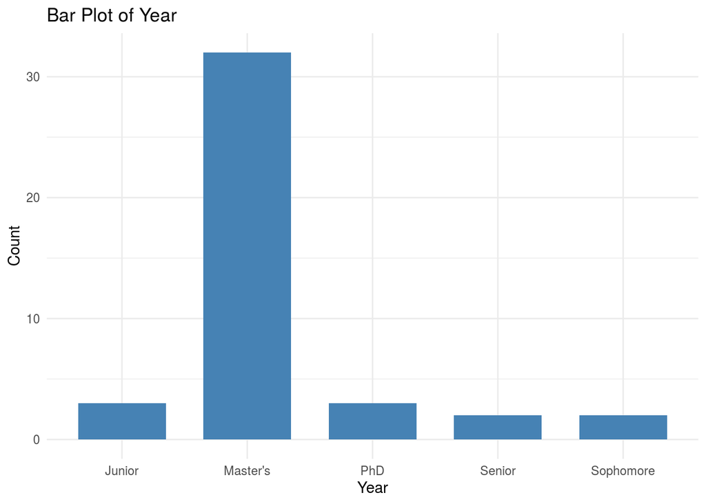

```r
filename <- "https://raw.githubusercontent.com/bcaffo/ds4ph-bme/master/data/classInterests.txt"
interests <- read.delim(filename, header = TRUE, sep = "\t")
ggplot(interests, aes(x=factor(Year)))+
  geom_bar(stat="count", width=0.7, fill="steelblue")+
  theme_minimal() + ggtitle("Bar Plot of Year") +
  xlab("Year") + ylab("Count")
```

Next I do Program

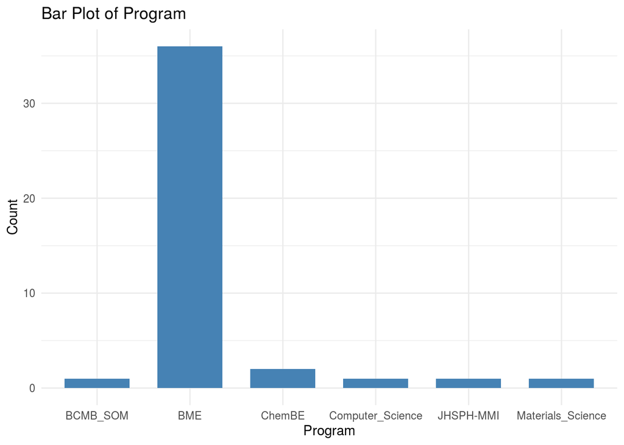

```r
ggplot(interests, aes(x=factor(Program)))+
  geom_bar(stat="count", width=0.7, fill="steelblue")+
  theme_minimal() + ggtitle("Bar Plot of Program") +
  xlab("Program") + ylab("Count")
```

## Question 3

Create a mosaic plot of the class data for year and program. It ends up a bit messy

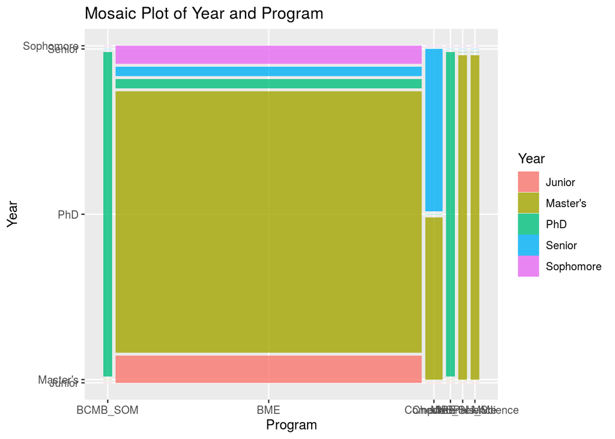

```r
ggplot(data = interests) +
  geom_mosaic(aes(x = product(Year, Program), fill=Year)) +
  labs(title='Mosaic Plot of Year and Program')
```

## Question 4

Download the gene expression dataset from here. Information about the data can be found in the sample info here. From the gene expression data matrix, subtract the rowmean from each row and the column mean from each column so that you have a new matrix that has been demeaned across both rows and columns.

```r
filename <- 'https://raw.githubusercontent.com/jhu-advdatasci/2018/master/data/GSE5859_exprs.csv'
dat <- read_csv(filename)
dat$X1 <- NULL
dat <- dat - rowMeans(dat)
dat <- dat - colMeans(dat)
#I decide to print out a few entries just to show the change
print(dat[1:4,1:4])
```

```
##   GSM25581.CEL.gz GSM25681.CEL.gz GSM136524.CEL.gz GSM136707.CEL.gz
## 1     -0.02448974      -0.6409817      -0.22715675       0.12348968
## 2      0.17103307       0.3037268       0.38367108      -0.07153284
## 3      0.28559505      -0.6659302      -0.43896668      -0.08035886
## 4     -0.66340221      -0.5707189      -0.03957877       0.35668450
```

## Question 5

Download the data from here. Create plots of healthcare spending versus time color coded by states.

```r
dat <- read_csv("https://raw.githubusercontent.com/jhu-advdatasci/2018/master/data/KFF/healthcare-spending.csv", skip = 2,  n_max = 52)
names(dat)[2:25] <- c("1991", "1992", "1993", "1994", "1995", "1996", "1997", "1998", "1999", "2000", "2001", "2002", "2003", "2004", "2005", "2006", "2007", "2008", "2009", "2010", "2011", "2012", "2013", "2014")
long_data<- dat %>% gather(key = "Year" , value = "Spending", c(-"Location"))
long_data$Spending=as.numeric(as.character(long_data$Spending))
long_data$Year <- as.numeric(as.vector(long_data$Year))
head(long_data)
```

```
## # A tibble: 6 x 3
##   Location       Year Spending
##   <chr>         <dbl>    <dbl>
## 1 United States  1991   675896
## 2 Alabama        1991    10393
## 3 Alaska         1991     1458
## 4 Arizona        1991     9269
## 5 Arkansas       1991     5632
## 6 California     1991    81438
```

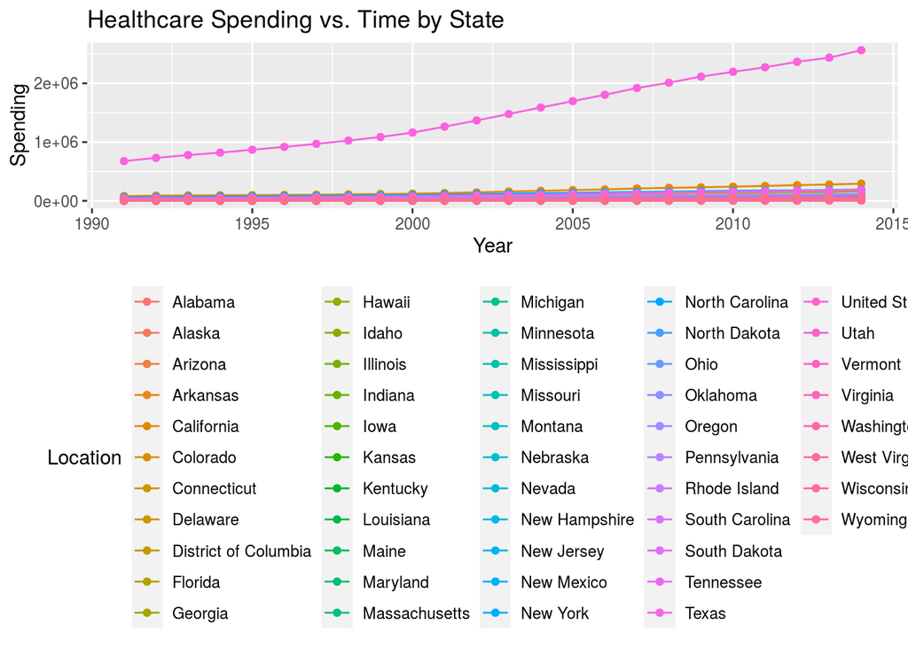

```r
p<-ggplot(long_data, aes(x=Year, y=Spending, group=Location)) +
  geom_line(aes(color=Location))+
  geom_point(aes(color=Location))+
  labs(title='Healthcare Spending vs. Time by State')
p + theme(legend.position="bottom")
```

## Question 5

Refer to the previous data. Create a barplot of average health care spending by state. This one sadly is a little messy

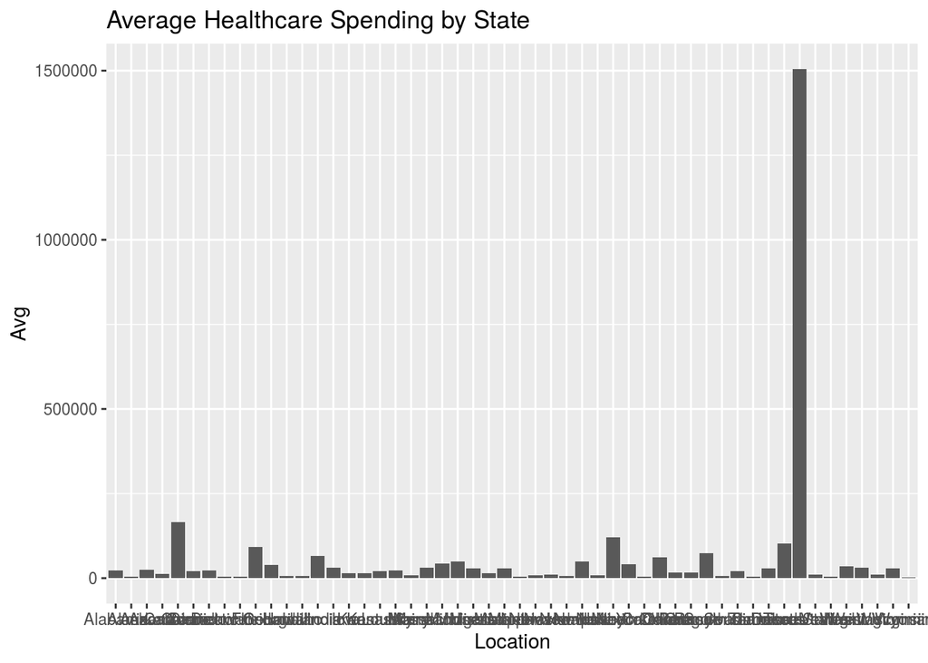

```r
dat$Avg <- rowMeans(dat[,2:25])
p<-ggplot(data=dat, aes(x=Location, y=Avg)) +
  geom_bar(stat="identity") +
  labs(title='Average Healthcare Spending by State')
p
```